# 95-791 Data Mining (Fall 2021) - B2 Final Project

## Recidivism Prediction

### Name: Jamie Lim, Thomas Tam, Tina Feng

# Objective

Recidivism, defined as an arrest for a new felony or misdemeanor crime within three years of the supervision start date, is an important measurement of supervision activities during the entire time people were under supervision or until the date of recidivism for those arrested.

We are interested in discovering patterns behind recidivism and therefore predicting recidivism using data mining techniques and governmental datasets.

Ideally, with well-understood relationships between recidivism and predictors, we can hopefully help reduce violent crime, and protect police and other public safety personnel by reducing recidivism.

## Description of Data

● Number of Observations: 25,835

● Number of Possible Target Variables (Y): 4 , all categorical variables Recidivism is measured as an arrest for a new felony or misdemeanor crime within three years of the supervision start date. The test dataset does not include the four dependent variables. Recidivism Within 3 years: Binary (0 = No, 1 = Yes) Recidivism_Arrest_Year1: Binary (0 = No, 1 = Yes) Recidivism_Arrest_Year2: Binary (0 = No, 1 = Yes) Recidivism_Arrest_Year3: Binary (0 = No, 1 = Yes)

● Number of Features (Xs): 48

● Number of numerical features: 8 (no. 7 and no. 42-48 in the codebook)

● Number of categorical features: 40

● There are 6 subgroups of features:

1. Supervision Case Information
2. Prison Case Information
3. Prior Georgia Criminal History
4. Prior Georgia Community Supervision History
5. Georgia Board of Pardons and Paroles Conditions of Supervision
6. Supervision Activities|

● Dataset Source: https://data.ojp.usdoj.gov/stories/s/daxx-hznc

## 1. Data Cleaning

```python
# take an initial look at the data
df.info()
```

```
<class 'pandas.core.frame.DataFrame'>
RangeIndex: 25835 entries, 0 to 25834
Data columns (total 54 columns):
 #   Column                                             Non-Null Count  Dtype
---  ------                                             --------------  -----
 0   ID                                                 25835 non-null  int64
 1   Gender                                             25835 non-null  object
 2   Race                                               25835 non-null  object
 3   Age_at_Release                                     25835 non-null  object
 4   Residence_PUMA                                     25835 non-null  int64
 5   Gang_Affiliated                                    22668 non-null  object
 6   Supervision_Risk_Score_First                       25360 non-null  float64
 7   Supervision_Level_First                            24115 non-null  object
 8   Education_Level                                    25835 non-null  object
 9   Dependents                                         25835 non-null  object
```

[output cut: 46 more lines]

#### Assumptions & Treatments for Features (including those with null)

Features not needed:

- `ID`: similar to index
- `Residence_PUMA`: out-of-scope geographical feature (could be useful for future analysis)
- `Avg_Days_per_DrugTest`: does not provide insights in recidivists' drug usage
- Training_Sample: not related

Fill Na:

- `Gang_Affiliated`:
  - Assumption: We assume observations with null value are not gang-affiliated
  - Treatment: fillna with 0
- `Prison_Offense`:
  - Assumption: This feature cannot be null (since all prisoners in prison has an offense), so we categorize null value as Other
  - Treatment: fillna with "Other"
- `DrugTests_THC_Positive`, `DrugTests_Cocaine_Positive`, `DrugTests_Meth_Positive`, `DrugTests_Other_Positive`:
  - Assumption: We assume observations with null value were not assigned drug tests, thereby having 0% positive rate in drug test results
  - Treatment: fillna with 0

For the remaining rows with Na, we just drop them because there is no appropriate approach to impute those values and they only count for around 10% of the whole dataset.

### 1c) Any other necessary conversation such as dealing with categorical variables, verifying each variable is the right type.

In our dataset, there are mostly categorical variables and we acknowledge that there are different methods to encode them, and some encoding method works better for some models. Hence, here in this submission we first explore ordinal encoding:

1. We apply get_dummies to do one-hot encoding for the following non-ordial categorical features:
   - `Supervision_Level_First`
   - `Prison_Offense`
2. We apply OrdinalEncoder, *with specific orders* for the following ordinal categorical features:
   - `Education_Level`
   - `Prison_Years`
3. We then apply OrdinalEncoder for the remaining categorical features, *without explicitly specifying orders*
4. Continuous features including `DrugTests_THC_Positive`,`DrugTests_Cocaine_Positive`, `DrugTests_Meth_Positive`, `DrugTests_Other_Positive`, `Percent_Days_Employed`, and `Jobs_Per_Year` will remain the same

*Since the scales for different features do not very a lot (0-10 compared to 0-1), we decide not to normalize our features (in fact, we also did a preliminary test with normalized features, and the result was the same with unnormalized one, which again justified our decision not to conduct normalization).*

## 2. Data Visualization

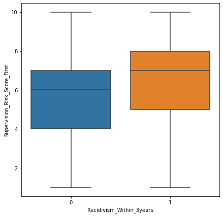

```python
# Plotting the value of first Supervision Risk  Assessment Score vs. Recidivised_Within_3years = True / False
plt.figure(figsize=(20,20))

plt.figure(figsize=(7, 7))
sns.boxplot(y="Supervision_Risk_Score_First", x="Recidivism_Within_3years", data=df_cleaned_viz)
# plt.savefig('risk score')
```

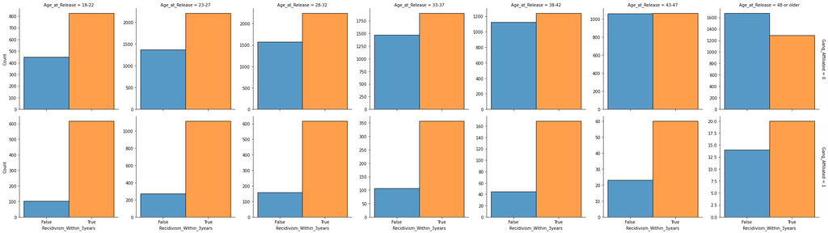

```python
# Plotting Age_at_Release on columns and Gang_affiliated on rows and hue showing Recidivised_Within_3years = True / False
plt.figure(figsize=(20,20))
plt.tight_layout(pad=2.0)

col_order = [ '18-22', '23-27', '28-32', '33-37', '38-42','43-47','48 or older']

g = sns.FacetGrid(df_cleaned_viz, col="Age_at_Release",col_order=col_order,  row="Gang_Affiliated", height = 4, margin_titles=True, hue = "Recidivism_Within_3years", sharey = False)
g.map_dataframe(sns.histplot, "Recidivism_Within_3years")
plt.xticks([0, 1], ['False', 'True'])
g.axes[0,0].set_ylabel('Count')
g.axes[1,0].set_ylabel('Count')


# g.savefig('Age vs. Gang')
```

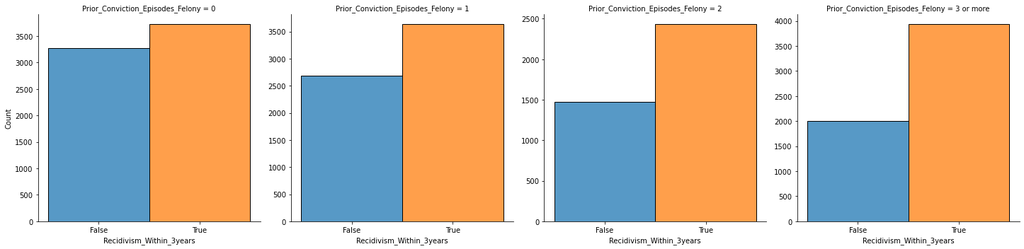

```python
# Felony
col_order = ['0','1','2','3 or more']
g = sns.FacetGrid(df_cleaned_viz, col="Prior_Conviction_Episodes_Felony", col_order=col_order, hue = "Recidivism_Within_3years", height = 5, sharey = False)
g.map_dataframe(sns.histplot, "Recidivism_Within_3years")

plt.xticks([0, 1], ['False', 'True'])
g.axes[0,0].set_ylabel('Count')
```

## 3. Three questions we want to answer with our dataset

1. Given an individual's criminal record, is he/she likely to recidivate* and what are the main features associated with recidivism? -Binary Classification
2. If an individual is classified as a potential recidivist, in which year* is he/she likely to recidivate and what features are associated with the difference in arrest years? -Multiclass Classification
3. What are the shared characteristics of subgroups of recidivists? -Clustering